# Obtaining odds ratios from logistic regression

Nicolás Molano Gonzalez

04 junio, 2021

# 1 Introduction

Odds ratios are the prefered effect measure in health sciences to describe asociations between a dichotumous outcome of interest and a categorical variable, most often dichotumous, but not always. Lets start this discution with an example.

## 1.1 Example1

Considere an study in which 250 patients are interrogated about having taken any vaccinations against seasonal flu (vac) and diagnostiqued in the past six monts with seasonal flu (flu).

Here we present the code to simulate some data for this essenario:

```r
#load packages
library(pacman)
p_load(here)
p_load(tidyverse)
p_load(reshape2)
p_load(boot)
p_load(epitools)
p_load(kableExtra)
p_load(knitr)
p_load(ggmosaic)
set.seed(150)

#simulation
ca_ctr_r<-.3
n<-250
nCA<-round(n*ca_ctr_r)
z0<-data.frame(status=c(rep("flu",nCA),rep("no_flu",n-nCA)))
z0$vac<-NA
exp_CA<-.35
exp_CTR<-.75
z0[z0$status %in% "flu","vac"]<-ifelse(runif(nCA)<exp_CA,"yes","no")
z0[z0$status %in% "no_flu","vac"]<-ifelse(runif(n-nCA)<exp_CTR,"yes","no")
z0$vac<-factor(z0$vac,levels = c("yes","no"))
z0$status<-factor(z0$status)
```

The data of the study is stored in the object `z0` here we present the summary:

```r
summary(z0)
```

```
##     status     vac
##  flu   : 75   yes:149
##  no_flu:175   no :101
```

An other way to summarize the info is in the following contingency table (1.1)

Table 1.1: contingency table of flu vs vac

| vac | status flu | status no_flu | Sum |
| --- | --- | --- | --- |
| yes | 20 | 129 | 149 |
| no | 55 | 46 | 101 |
| Sum | 75 | 175 | 250 |

The main interest in this study is to determine if the proportion of patients diagnostiqued with `flu` is diferent depending on the intake of the vaccine. A first approach to this, is to compute conditional proportions of infections for those that were exposed to the vaccine and for those who not. This is easly done by calculating the row proportions in the table 1.1, as shown below

Table 1.2: row proportions of flu vs vac

| vac | status flu | status no_flu |
| --- | --- | --- |
| yes | 0.1342282 | 0.8657718 |
| no | 0.5445545 | 0.4554455 |

As can be seen in table 1.2, proportion of infections is higher in the group of no vaccination. Lets calculate de OR for this table, defined as:

$$\begin{equation}
OR(flu|vac=yes \; vs \; vac=no)=\frac{\frac{P(flu|vac=yes)}{1-P(flu|vac=yes)}}{\frac{P(flu|vac=no)}{1-P(flu|vac=no)}} \tag{1.1}
\end{equation}$$

Where $P(flu|vac=yes)$ stands for the proportion of patients with flu which were previously vaccinted, or more exactly, in terms of conditional probabilities: the probability of being infected with `flu` given that the subject has been vaccinated . Similarly $P(flu|vac=no)$ stands for the proportion of patients with flu which did not recive any vaccination.

We have adopted here the notation
$$OR(flu|vac=yes \; vs \; vac=no)$$
in order to specify that the outcome of interest is $flu$ and that this outcome is being compared in $vac=yes$ vs $vac=no$ groups. This detailed notation will be usefull to highlight some propoerties of the OR later.

Let us calculate this OR ussing function `oddsratio` from packatge `epitools`:

```r
(or1<-t(table(z0))%>%oddsratio)
```

```
## $data
##        status
## vac     flu no_flu Total
##   yes    20    129   149
##   no     55     46   101
##   Total  75    175   250
##
## $measure
##      odds ratio with 95% C.I.
## vac   estimate      lower    upper
##   yes 1.000000         NA       NA
##   no  0.131502 0.06972638 0.239498
##
## $p.value
##      two-sided
## vac     midp.exact fisher.exact  chi.square
##   yes           NA           NA          NA
##   no  4.708234e-12 4.552077e-12 3.72874e-12
##
## $correction
## [1] FALSE
##
## attr(,"method")
## [1] "median-unbiased estimate & mid-p exact CI"
```

Therefore $OR(flu|vac=yes \; vs \; vac=no)=$ 0.131502, and the $95\% \; CI=$ (0.0697264, 0.239498)

It is very important to note that the different OR’s can be computed from this same table. If we transpose the table we get this

Table 1.3: contingency table of vac vs flu

| flu | vac yes | vac no | Sum |
| --- | --- | --- | --- |
| flu | 20 | 55 | 75 |
| no_flu | 129 | 46 | 175 |
| Sum | 149 | 101 | 250 |

Calculating the OR from this table we obtain the following:

$$\begin{equation}
OR(vac=yes|flu \; vs \; no\; flu)=\frac{\frac{P(vac=yes|flu)}{1-P(vac=yes|flu)}}{\frac{P(vac=yes|no \;flu)}{1-P(vac=yes|no \;flu)}} \tag{1.2}
\end{equation}$$

Now, $P(vac=yes|flu)$ stands for the proportion of patients with flu that were vaccinated and $P(vac=yes|no \;flu)$ stands for the proportion of patients without flu which recived any vaccination. Therefore

```r
(or2<-table(z0)%>%oddsratio)
```

```
## $data
##         vac
## status   yes  no Total
##   flu     20  55    75
##   no_flu 129  46   175
##   Total  149 101   250
##
## $measure
##         odds ratio with 95% C.I.
## status   estimate      lower    upper
##   flu    1.000000         NA       NA
##   no_flu 0.131502 0.06972638 0.239498
##
## $p.value
##         two-sided
## status     midp.exact fisher.exact  chi.square
##   flu              NA           NA          NA
##   no_flu 4.708234e-12 4.552077e-12 3.72874e-12
##
## $correction
## [1] FALSE
##
## attr(,"method")
## [1] "median-unbiased estimate & mid-p exact CI"
```

$OR(vac=yes|flu \; vs \; no flu)=$ 0.131502, and the $95\% \; CI=$ (0.0697264, 0.239498)

As can be seen
$$OR(flu|vac=yes \; vs \; vac=no)=OR(vac=yes|flu \; vs \; no \;flu)$$
although they are the same, the conditional probabilities analysed are very different

Table 1.2: row proportions of flu vs vac

| vac | status flu | status no_flu |
| --- | --- | --- |
| yes | 0.1342282 | 0.8657718 |
| no | 0.5445545 | 0.4554455 |

Table 1.4: row proportions of vac vs flu

| flu | vac yes | vac no |
| --- | --- | --- |
| flu | 0.2666667 | 0.7333333 |
| no_flu | 0.7371429 | 0.2628571 |

Still, there exist another possible OR calculation for the same data set. Consider swaping the columns in table 1.1, obtaining this:

Table 1.5: contingency table of flu vs vac

| vac | status no_flu | status flu | Sum |
| --- | --- | --- | --- |
| yes | 129 | 20 | 149 |
| no | 46 | 55 | 101 |
| Sum | 175 | 75 | 250 |

calculating the OR for this table now looks like this:
$$\begin{equation}
OR(no \;flu|vac=yes \; vs \; vac=no)=\frac{\frac{P(no \;flu|vac=yes)}{1-P(no \;flu|vac=yes)}}{\frac{P(no \;flu|vac=no)}{1-P(no \;flu|vac=no)}} \tag{1.3}
\end{equation}$$

where $P(no \; flu|vac=yes)=1-P(flu|vac=yes)$ and $P(no \; flu|vac=no)=1-P(flu|vac=no)$. Therefore

```r
z0$status<-factor(z0$status,levels = c("no_flu","flu"))
(or3<-t(table(z0))%>%oddsratio)
```

```
## $data
##        status
## vac     no_flu flu Total
##   yes      129  20   149
##   no        46  55   101
##   Total    175  75   250
##
## $measure
##      odds ratio with 95% C.I.
## vac   estimate    lower    upper
##   yes 1.000000       NA       NA
##   no  7.604921 4.175401 14.34177
##
## $p.value
##      two-sided
## vac     midp.exact fisher.exact  chi.square
##   yes           NA           NA          NA
##   no  4.708234e-12 4.552077e-12 3.72874e-12
##
## $correction
## [1] FALSE
##
## attr(,"method")
## [1] "median-unbiased estimate & mid-p exact CI"
```

$OR(no \; flu|vac=yes \; vs \; vac=no)=$ 7.6049208, and the $95\% \; CI=$ 4.1754008, 14.3417745

You can verify that indeed

$$OR(flu|vac=yes \; vs \; vac=no)=\frac{1}{OR(no\;flu|vac=yes \; vs \; vac=no)}$$
In conclucion, for a $2 \times 2$ table two different OR’s can be computed and they are related since one is the multiplicative inverse of the other. However there exist more than two posible configurations for the contingency table associated with this two OR and the configuration of the table is very important since it is related with the conditional probabilities analysed.

# 2 Odds ratios for $K \times 2$ tables

OR’s can be used to characterize the associations of between a dichotomous outcome of interest and a categorical variable with more than two categories. Consider the next example.

## 2.1 Example 2

A researcher has 1000 mice which were assigned randomly to one of 3 treatments: A, B, C. The researchers were interested in how the treatment is related to behavior modifications ($BM=Yes$) or not ($BM=No$). Here is the code to simulate this data set:

```r
N<-1000

treatment<-sample(LETTERS[1:3],N,replace =T)

cons<-NA
cons[treatment %in% "A"]<-rnorm(sum(treatment %in% "A"),100,10)
cons[treatment %in% "B"]<-rnorm(sum(treatment %in% "B"),100,10)
cons[treatment %in% "C"]<-rnorm(sum(treatment %in% "C"),100,10)

sim_probs<-rep(NA,N)

eqmA<-matrix(c(1,min(cons),
               1,max(cons)),byrow = T,nrow=2)
eqbA<-qlogis(c(.01,.6))
Abetas<-solve(eqmA,eqbA)

eqmB<-matrix(c(1,min(cons),
               1,max(cons)),byrow = T,nrow=2)
eqbB<-qlogis(c(.3,.9))
Bbetas<-solve(eqmB,eqbB)

eqmC<-matrix(c(1,min(cons),
               1,max(cons)),byrow = T,nrow=2)
eqbC<-qlogis(c(.99,.4))
Cbetas<-solve(eqmC,eqbC)

sim_probs[treatment %in% "A"]<-inv.logit(Abetas[1]+Abetas[2]*cons[treatment %in% "A"])
sim_probs[treatment %in% "B"]<-inv.logit(Bbetas[1]+Bbetas[2]*cons[treatment %in% "B"])
sim_probs[treatment %in% "C"]<-inv.logit(Cbetas[1]+Cbetas[2]*cons[treatment %in% "C"])

z1<-data.frame(treatment,cons,sim_probs,stringsAsFactors = T)
z1$BM<-map_dbl(z1$sim_probs,~rbinom(1,1,.))
z1$BM<-factor(z1$BM,level=0:1,labels = c("No","Yes"))
```

Data is stored in object z1. Table 2.1 presents the results of this experiment.

Table 2.1: contingency table of treatment vs behavior modifications

| treatment | BM Yes | BM No | Sum |
| --- | --- | --- | --- |
| A | 49 | 267 | 316 |
| B | 230 | 118 | 348 |
| C | 286 | 50 | 336 |
| Sum | 565 | 435 | 1000 |

It must be noted that the objective of this experiment is to study the following conditional probabilities:
$$P(BM=Yes|Treatment=A), \;(BM=Yes|Treatment=B), \;(BM=Yes|Treatment=C)$$
And to assess wether they differ at all, which is biger, etc. How OR’s can help us to characterize the change in conditional distributions of behavior modifications given the treatments assigned? OR’s are designed to measure the association between dichotomous variables, however, here one of the variables has 3 categories. The key is to note that in table 2.1 there exist several $2 \times 2$ tables for example

Table 2.2: a) rows A and B

| treatment | BM Yes | BM No | Sum |
| --- | --- | --- | --- |
| A | 49 | 267 | 316 |
| B | 230 | 118 | 348 |
| Sum | 279 | 385 | 664 |

Table 2.2: b) rows A and C

| treatment | BM Yes | BM No | Sum |
| --- | --- | --- | --- |
| A | 49 | 267 | 316 |
| C | 286 | 50 | 336 |
| Sum | 335 | 317 | 652 |

So in these tables we can, indeed, calculate OR’s, those OR’s will asses the following differences (or contrasts):

$$P(BM=Yes|Treatment=A)\; vs \;(BM=Yes|Treatment=B)$$
and
$$P(BM=Yes|Treatment=A)\; vs \;(BM=Yes|Treatment=C)$$

The corresponding OR’s are $OR(BM=Yes|A vs B)$ and $OR(BM=Yes|A vs C)$. In this setting, we are selecting treatment $A$ as the reference treatment, comparing the remaining treatments with it. Lets calculate those OR’s.

```r
table(z1$treatment,z1$BM) %>% oddsratio()
```

```
## $data
##
##         Yes  No Total
##   A      49 267   316
##   B     230 118   348
##   C     286  50   336
##   Total 565 435  1000
##
## $measure
##    odds ratio with 95% C.I.
##       estimate      lower     upper
##   A 1.00000000         NA        NA
##   B 0.09474674 0.06438861 0.1371569
##   C 0.03244123 0.02087136 0.0492784
##
## $p.value
##    two-sided
##     midp.exact fisher.exact   chi.square
##   A         NA           NA           NA
##   B          0 7.018603e-42 1.015235e-39
##   C          0 4.029024e-77 1.133423e-70
##
## $correction
## [1] FALSE
##
## attr(,"method")
## [1] "median-unbiased estimate & mid-p exact CI"
```

Here we present a more friendly table:

Table 2.3: OR’s for reference treatment A, with 95% confidence intervals

|  | estimate | lower | upper |
| --- | --- | --- | --- |
| A | 1.0000000 | NA | NA |
| B | 0.0947467 | 0.0643886 | 0.1371569 |
| C | 0.0324412 | 0.0208714 | 0.0492784 |

So it seem that treatment $A$ has fewer cases of behavior modifications compared to the other treatments. It would be nice to have a graph wich allows us to see this more clearly. In fact this graph exists and is called **mosaic plot**

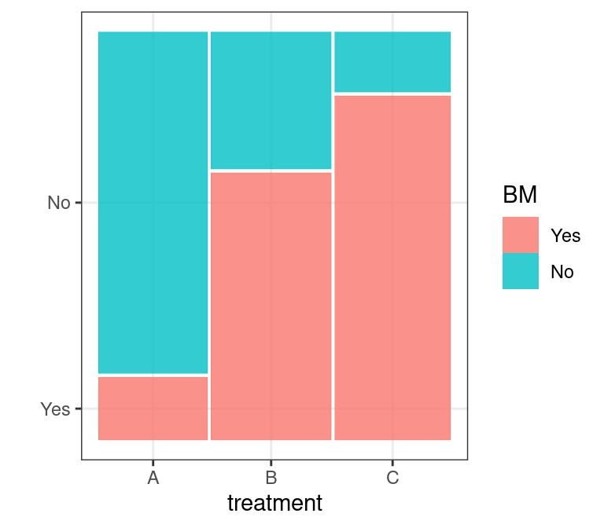

Figure 2.1: mosaic plot for BM conditional probabiliteis

This OR’s approach for this $3\times 2$ can be modified, changing the reference treatment and obtaining different OR’s. As stated in the previous section the order of the rows ans columns maters, so if we swap, columns different OR’s will be obtained, however it can be checked that these OR’s for the swapped columns are the multiplicative inverse of the ones presented here.

# 3 Logistic regression

Logistic regression was developed as an extension of the linear regression when the outcome of interest is a variable following a binomial distribution. However, most of the cases in health sciences the outcome of interest is distributed as a Bernoulli which is simply a binomial distribution where $n=1$.

Let us consider an outcome variable of interest $Y$ which has values of $yes$ and $no$ (like presence of disease, death, and so on). Assume now, that $P(Y=yes)$ is the probability of interest in the study and the aim of the study is to evaluate how this probability changes for different characteristics of the study subjects, like gender, age and other possible “covariates.”

This led us to the study of the conditional probability of $P(Y=yes)$ given arbitrary values in the covariates, in general that is:

$$\begin{equation}
P(Y=yes|X_1=x_1,X_2=x_2,...,X_p=x_p) \tag{3.1}
\end{equation}$$
Where $X1,...,X_p$ are random variables (the covariates) and $x_1,...,x_p$ are arbitrary values of these covariates.

In order to study those conditional probabilities (3.1), statisticians have developed the following model:

$$\begin{equation}
Ln \left(\frac{P(Y=yes|X_1=x_1,X_2=x_2,...,X_p=x_p)}{1-P(Y=yes|X_1=x_1,X_2=x_2,...,X_p=x_p)}\right)=
\beta_0+\beta_1x_1+\beta_2x_2+...+\beta_px_p\tag{3.2}
\end{equation}$$

Model (3.2) is known as the **Logistic Regression**. The cuantity

$$\begin{equation}
\frac{P(Y=yes|X_1=x_1,X_2=x_2,...,X_p=x_p)}{1-P(Y=yes|X_1=x_1,X_2=x_2,...,X_p=x_p)}\tag{3.3}
\end{equation}$$

is known as the **odds** and is simple the probability of a given event divided by the probability of it not occurring.

Let us explore this model with the data of previous examples

## 3.1 Example 1 revisited

Here we present briefly the data of example 1, flu vs vaccination:

Table 3.1: contingency table of flu vs vac

| vac | status no_flu | status flu | Sum |
| --- | --- | --- | --- |
| yes | 129 | 20 | 149 |
| no | 46 | 55 | 101 |
| Sum | 175 | 75 | 250 |

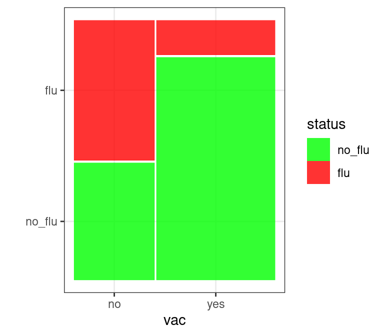

Figure 3.1: mosaic plot for flu conditional probabiliteis

We will fit the following model:

$$\begin{equation}
Ln \left(\frac{P(Status=flu|X_{vac}=x)}{1-P(Status=flu|X_{vac}=x))}\right)=\beta_0+\beta_1x\tag{3.4}
\end{equation}$$

Where $X_{vac}$ is a dummy variable encoding categorical variable $vac$, $X_{vac}= 0$ if $vac=no$ and $X_{vac}= 1$ if $vac=yes$. Let us explore how the model (3.4) behaves.

First we will check the behavior of the model when people is not vaccinated, that is $vac=no$ or $X_{vac}= 0$, which is the same. So replacing the appropriate values in model (3.4) we got:

$$\begin{equation}
Ln \left(\frac{P(Status=flu|X_{vac}=0)}{1-P(Status=flu|X_{vac}=0))}\right)=\beta_0+\beta_1 \times 0= \beta_0 \tag{3.5}
\end{equation}$$

Therefore, $\beta_0$ is just the natural logaritm of the odds of present flu when people os not vaccinated.

Now let us check the case when people is actually vaccinated, that is $vac=yes$ or $X_{vac}= 1$, which is the same:

$$Ln \left(\frac{P(Status=flu|X_{vac}=1)}{1-P(Status=flu|X_{vac}=1))}\right)=\beta_0+\beta_1 \times 1= \beta_0+\beta_1$$
Since we already have the value of $\beta_0$ (3.5) the above can be rewritten as
$$Ln \left(\frac{P(Status=flu|X_{vac}=1)}{1-P(Status=flu|X_{vac}=1))}\right)=Ln \left(\frac{P(Status=flu|X_{vac}=0)}{1-P(Status=flu|X_{vac}=0))}\right)+\beta_1$$
And now, solving for $\beta_1$ we get

$$\begin{equation}
\beta_1=Ln \left(\frac{P(Status=flu|X_{vac}=1)}{1-P(Status=flu|X_{vac}=1))}\right)-Ln\left(\frac{P(Status=flu|X_{vac}=0)}{1-P(Status=flu|X_{vac}=0))}\right)= \\
Ln \left( \frac{\frac{P(Status=flu|X_{vac}=1)}{1-P(Status=flu|X_{vac}=1))}}{\frac{P(Status=flu|X_{vac}=0)}{1-P(Status=flu|X_{vac}=0))}} \right)
\tag{3.6}
\end{equation}$$

Therefore, $\beta_1$ is the natural logaritm of $OR(flu|vac=yes \; vs \; vac=no)$.

Now we will show how to fit this model in R

### 3.1.1 Fitting model for example 1

First of all, is very important to check the order of the categories of each variable in R. We can do this by simply using function `levels`:

```r
levels(z0$status)
```

```
## [1] "no_flu" "flu"
```

```r
levels(z0$vac)
```

```
## [1] "no"  "yes"
```

so we see that the **reference** category for variable `status` is `no_flu` and for variable `vac` is `no`.

Now we fit the logistic regression model (3.4) as follows:

```r
m0<-glm(status~vac,data = z0,family = binomial)
summary(m0)
```

```
##
## Call:
## glm(formula = status ~ vac, family = binomial, data = z0)
##
## Deviance Residuals:
##     Min       1Q   Median       3Q      Max
## -1.2542  -0.5369  -0.5369   1.1025   2.0041
##
## Coefficients:
##             Estimate Std. Error z value Pr(>|z|)
## (Intercept)   0.1787     0.1998   0.894    0.371
## vacyes       -2.0428     0.3125  -6.536 6.31e-11 ***
## ---
## Signif. codes:  0 '***' 0.001 '**' 0.01 '*' 0.05 '.' 0.1 ' ' 1
##
## (Dispersion parameter for binomial family taken to be 1)
##
##     Null deviance: 305.43  on 249  degrees of freedom
## Residual deviance: 256.73  on 248  degrees of freedom
## AIC: 260.73
##
## Number of Fisher Scoring iterations: 4
```

We confirm that the codification of variable `vac` is the same as specified in model (3.4) (can you understand why?).

The first thing is to confirm that we actually are modelling $P(flu)$. We will confirm this by predicting the probability of being infected with flu for vaccinated and not vaccinated, using function `predict`

```r
#prediction for vac="no"
predict(m0,data.frame(vac="no"),type ="response")
```

```
##         1
## 0.5445545
```

```r
#prediction for vac="yes"
predict(m0,data.frame(vac="yes"),type ="response")
```

```
##         1
## 0.1342282
```

```r
#conditional proportions based on data
t(table(z0))%>%prop.table(1)
```

```
##      status
## vac      no_flu       flu
##   no  0.4554455 0.5445545
##   yes 0.8657718 0.1342282
```

As we can see, the predictions are the same as the conditional proportions calculated from the data. This confirms that model `m0` is actually especified as equation (3.4). This is so, because of the reference category structure in `data.frame` `z0`.

### 3.1.2 Fitting model for example 1: working with $P(no\;flu)$

I will now show a model where we actually are modeling $P(no\;flu)$. This is achieved by just changing the reference category in variable no_flu `status`. For this I will create a copy of `z0` named `z00` and change de reference category of variable `status`. After that I will fit the `glm` model:

```r
#copy df
z00<-z0
#changing reference category
z00$status<-relevel(z00$status,ref="flu")
#fitting the model
m00<-glm(status~vac,data = z00,family = binomial)
summary(m00)
```

```
##
## Call:
## glm(formula = status ~ vac, family = binomial, data = z00)
##
## Deviance Residuals:
##     Min       1Q   Median       3Q      Max
## -2.0041  -1.1025   0.5369   0.5369   1.2542
##
## Coefficients:
##             Estimate Std. Error z value Pr(>|z|)
## (Intercept)  -0.1787     0.1998  -0.894    0.371
## vacyes        2.0428     0.3125   6.536 6.31e-11 ***
## ---
## Signif. codes:  0 '***' 0.001 '**' 0.01 '*' 0.05 '.' 0.1 ' ' 1
##
## (Dispersion parameter for binomial family taken to be 1)
##
##     Null deviance: 305.43  on 249  degrees of freedom
## Residual deviance: 256.73  on 248  degrees of freedom
## AIC: 260.73
##
## Number of Fisher Scoring iterations: 4
```

let us now check the predicted probabilities as before:

```r
#prediction for vac="no"
predict(m00,data.frame(vac="no"),type ="response")
```

```
##         1
## 0.4554455
```

```r
#prediction for vac="yes"
predict(m00,data.frame(vac="yes"),type ="response")
```

```
##         1
## 0.8657718
```

```r
#conditional proportions based on data
t(table(z00))%>%prop.table(1)
```

```
##      status
## vac         flu    no_flu
##   no  0.5445545 0.4554455
##   yes 0.1342282 0.8657718
```

with this you can see that model `m00` is working indeed with $P(no\;flu)$. This shows the importance of reference category when running a model.

### 3.1.3 OR from logistic regresion

We are back to our model of $P(flu)$. We saw that, in the end, parameter $\beta_1$ in model (3.4) is just the natural logarithm of an OR (3.6), namely $OR(flu|vac=yes \; vs \; vac=no)$. In model `m0` the estimation of $\beta_1$ is `-2.0427719` that is:

$$Ln \left( OR(flu|vac=yes \; vs \; vac=no) \right)=-2.0427719$$
In order to get the OR valur we just need to apply the inverse function of the natural logarithm, that is the exponential function (`exp` in R)

```r
coef(m0)[2] %>% exp
```

```
##    vacyes
## 0.1296688
```

We can compare this with the value of the OR computed from the `oddsratio` function, stored previously in object `or1`:

```r
#conventional contingency table for OR calculation
or1$data
```

```
##        status
## vac     flu no_flu Total
##   yes    20    129   149
##   no     55     46   101
##   Total  75    175   250
```

```r
#OR estimation
or1$measure["no",]
```

```
##   estimate      lower      upper
## 0.13150201 0.06972638 0.23949797
```

The values are not exactly equal but are quite similar. This diference is due to the fact that function `oddsratio` uses a different method to estimate the OR as compared to the procedure used in the logistic regression.

## 3.2 Example 2 revisited

Now we are going to use the logistic regression model to analyse data from example 2. Here we present briefly the data, treatment vs behavior modifications:

```r
table(z1[,c("treatment","BM")])%>%addmargins
```

```
##          BM
## treatment  Yes   No  Sum
##       A     49  267  316
##       B    230  118  348
##       C    286   50  336
##       Sum  565  435 1000
```

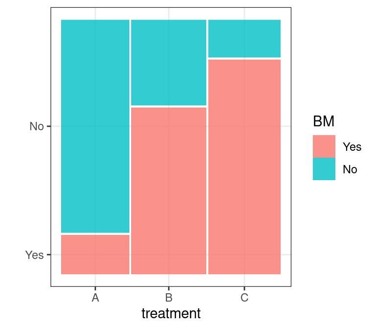

Figure 3.2: mosaic plot for BM conditional probabiliteis

Since we will be interested in modeling $P(BM=yes)$ we now change category `No` to be reference for variable `BM` and fit the model:

```r
z1$BM<-relevel(z1$BM,ref="No")
m1<-glm(BM~treatment,data = z1,family = binomial)
summary(m1)
```

```
##
## Call:
## glm(formula = BM ~ treatment, family = binomial, data = z1)
##
## Deviance Residuals:
##     Min       1Q   Median       3Q      Max
## -1.9520  -0.5805   0.5677   0.9101   1.9308
##
## Coefficients:
##             Estimate Std. Error z value Pr(>|z|)
## (Intercept)  -1.6954     0.1554  -10.91   <2e-16 ***
## treatmentB    2.3628     0.1923   12.29   <2e-16 ***
## treatmentC    3.4394     0.2183   15.76   <2e-16 ***
## ---
## Signif. codes:  0 '***' 0.001 '**' 0.01 '*' 0.05 '.' 0.1 ' ' 1
##
## (Dispersion parameter for binomial family taken to be 1)
##
##     Null deviance: 1369.3  on 999  degrees of freedom
## Residual deviance: 1001.0  on 997  degrees of freedom
## AIC: 1007
##
## Number of Fisher Scoring iterations: 4
```

Mathemathical specification of this model is as follows:

$$\begin{equation}
Ln \left( \frac{P(BM=Yes|treatmentB=x_1,treatmentC=x_2)}{1-P(BM=Yes|treatmentB=x_1,treatmentC=x_2)}\right)=\beta_0+\beta_1x_1+\beta_2x_2 \tag{3.7}
\end{equation}$$

where $treatmentB$ and $treatmentC$ are dummy variables used to encode the categorixal variable treatment, as follows:

Table 3.2: reference coding for treatment

| treatment | treatmentB | treatmentC |
| --- | --- | --- |
| A | 0 | 0 |
| B | 1 | 0 |
| C | 0 | 1 |

Let us now inspect how this model behaves for each treatment. let’s start for category `A` : since, for this treatment $treatmentB=0$ and $treatmentC=0$ then equation (3.7) yields:

$$\begin{equation}
Ln \left( \frac{P(BM=Yes|treatmentB=0,treatmentC=0)}{1-P(BM=Yes|treatmentB=0,treatmentC=0)}\right)=
\beta_0+\beta_1 \times 0+\beta_2 \times 0 = \beta_0 \tag{3.8}
\end{equation}$$

As before, $\beta_0$ is just the natural logaritm of the odds of present $BM=Yes$ on treatment $A$.

Now for treatment $B$:

$$Ln \left( \frac{P(BM=Yes|treatmentB=1,treatmentC=0)}{1-P(BM=Yes|treatmentB=1,treatmentC=0)}\right)=
\beta_0+\beta_1 \times 1+\beta_2 \times 0 = \beta_0+\beta_1$$

Since when already have the value of $\beta_0$ (3.8) the above can be rewritten as

$$Ln \left( \frac{P(BM=Yes|treatmentB=1,treatmentC=0)}{1-P(BM=Yes|treatmentB=1,treatmentC=0)}\right)=
Ln \left( \frac{P(BM=Yes|treatmentB=0,treatmentC=0)}{1-P(BM=Yes|treatmentB=0,treatmentC=0)}\right)+\beta_1$$

And now, solving for $\beta_1$ we get

$$\begin{equation}
\beta_1 = Ln \left( \frac{P(BM=Yes|treatmentB=1,treatmentC=0)}{1-P(BM=Yes|treatmentB=1,treatmentC=0)}\right)-
Ln \left( \frac{P(BM=Yes|treatmentB=0,treatmentC=0)}{1-P(BM=Yes|treatmentB=0,treatmentC=0)}\right)= \\
Ln\left(\frac{\frac{P(BM=Yes|treatmentB=1,treatmentC=0)}{1-P(BM=Yes|treatmentB=1,treatmentC=0)}}{ \frac{P(BM=Yes|treatmentB=0,treatmentC=0)}{1-P(BM=Yes|treatmentB=0,treatmentC=0)}} \right)
\tag{3.9}
\end{equation}$$

Therefore, $\beta_1$ is the natural logaritm of $OR(BM=Yes| treatment=B \; vs \; treatment=A)$.

Finally the same analysis for treatment $C$ produces

$$\begin{equation}
\beta_2 = Ln \left( \frac{P(BM=Yes|treatmentB=0,treatmentC=1)}{1-P(BM=Yes|treatmentB=0,treatmentC=1)}\right)-
Ln \left( \frac{P(BM=Yes|treatmentB=0,treatmentC=0)}{1-P(BM=Yes|treatmentB=0,treatmentC=0)}\right)= \\
Ln\left(\frac{\frac{P(BM=Yes|treatmentB=0,treatmentC=1)}{1-P(BM=Yes|treatmentB=0,treatmentC=1)}}{ \frac{P(BM=Yes|treatmentB=0,treatmentC=0)}{1-P(BM=Yes|treatmentB=0,treatmentC=0)}} \right)
\tag{3.10}
\end{equation}$$

Therefore, $\beta_2$ is the natural logaritm of $OR(BM=Yes| treatment=C \; vs \; treatment=A)$.

taking this into account we have that:

- $Ln(OR(BM=Yes| treatment=B \; vs \; treatment=A))=2.362823$
- $Ln(OR(BM=Yes| treatment=C \; vs \; treatment=A))=3.4393972$

as can be seen in `summary(m1)`

### 3.2.1 Exampe 2: OR from logistic regresion vs clasical OR

OR’s obtained from logistic regression model (3.7) are not the same as those obtained by means of the function `oddsratio`. The OR’s from that functions are these:

```r
# use param rev to change order of columns
# and obtain the clasical configuration of the contingency table
oddsratio(table(z1$treatment,z1$BM),rev ="columns")
```

```
## $data
##
##         Yes  No Total
##   A      49 267   316
##   B     230 118   348
##   C     286  50   336
##   Total 565 435  1000
##
## $measure
##    odds ratio with 95% C.I.
##       estimate      lower     upper
##   A 1.00000000         NA        NA
##   B 0.09474674 0.06438861 0.1371569
##   C 0.03244123 0.02087136 0.0492784
##
## $p.value
##    two-sided
##     midp.exact fisher.exact   chi.square
##   A         NA           NA           NA
##   B          0 7.018603e-42 1.015235e-39
##   C          0 4.029024e-77 1.133423e-70
##
## $correction
## [1] FALSE
##
## attr(,"method")
## [1] "median-unbiased estimate & mid-p exact CI"
```

Here the OR’s obtained are

- $OR(BM=Yes| treatment=A \; vs \; treatment=B)$
- $OR(BM=Yes| treatment=A \; vs \; treatment=C)$

which are simply the multiplicative invereses of the OR’s obtained trough logistic regresion model (3.7). Asuming that the OR’s of interest are those presented above, we would want to calculate those from the model (3.7). This is simple and is shown below:

```r
coef(m1)[-1] %>% {exp(-.)}
```

```
## treatmentB treatmentC
## 0.09415405 0.03208402
```

this means that

$$\begin{equation}
OR(BM=Yes| treatment=A \; vs \; treatment=B)=exp(-\beta_1)=0.094154 \\
OR(BM=Yes| treatment=A \; vs \; treatment=C)=exp(-\beta_2)=0.032084
\tag{3.11}
\end{equation}$$

which are quite similar to those obtained trough function `oddsratio`. For these OR’s confidense intervals would be also calculated as follows:

```r
confint(m1)[-1,] %>% {exp(-.)}
```

```
##                 2.5 %     97.5 %
## treatmentB 0.13623569 0.06404866
## treatmentC 0.04871699 0.02068486
```

you should note that they are inverted, can you understand why is this?

# 4 Conclucions

We have shown how OR’s works, in particular the configuration of columns and rows in a contingency table are very important in order to determine the type of OR calculated.

We also have introduced the notation

$$OR(y|A \;vs \; B)$$
in order to avoid any confusion about the probabilities involved in the calculation of the OR of interest. Here $y$ is the outcome of interest and $A$ and $B$ are the groups where we are interested in compare the precense of outcome $y$.

Once clarified the concepts around the OR we show how to estimate them by means of the logistic regression. Here, again, the reference category concept as well as the reference encoding for categorical variables are of paramount importance to specify the model and to obtain the desired OR’s.

In an other document we will discus the concept of “adjusted” OR and how to calculate it and interpret it using the logistic regression model.